# Analysis

[Note: We have included anaysis and interpretations for each of these models and plots in our writeup, so here, we present only the code and very brief explanation.]

Load data for Mandarin corpus

```r
mandarin <- read_csv('/Users/Yuqi/Desktop/english-l2-learner-corpus/cleaned_csv/mandarin_L1_nltk.csv')
count_uniq_words_mandarin <- read_csv('/Users/Yuqi/Desktop/english-l2-learner-corpus/cleaned_csv/mandarin_l1_lemmatizer_column.csv')

combined_mandarin <- inner_join(mandarin, count_uniq_words_mandarin, by=c("Filename"="file_id"))
```

Load data for Spanish corpus

```r
spanish <- read_csv('/Users/Yuqi/Desktop/english-l2-learner-corpus/cleaned_csv/spanish_L1_nltk.csv')
count_uniq_words_spanish <- read_csv('/Users/Yuqi/Desktop/english-l2-learner-corpus/cleaned_csv/spanish_l1_lemmatizer_column.csv')

combined_spanish <- inner_join(spanish, count_uniq_words_spanish, by=c("Filename"="file_id"))
```

### Proxies for English proficiency

Density plot of number of unique words, categorized by score level. Higher number of unique words leads to higher score level.

Mandarin L1 corpus

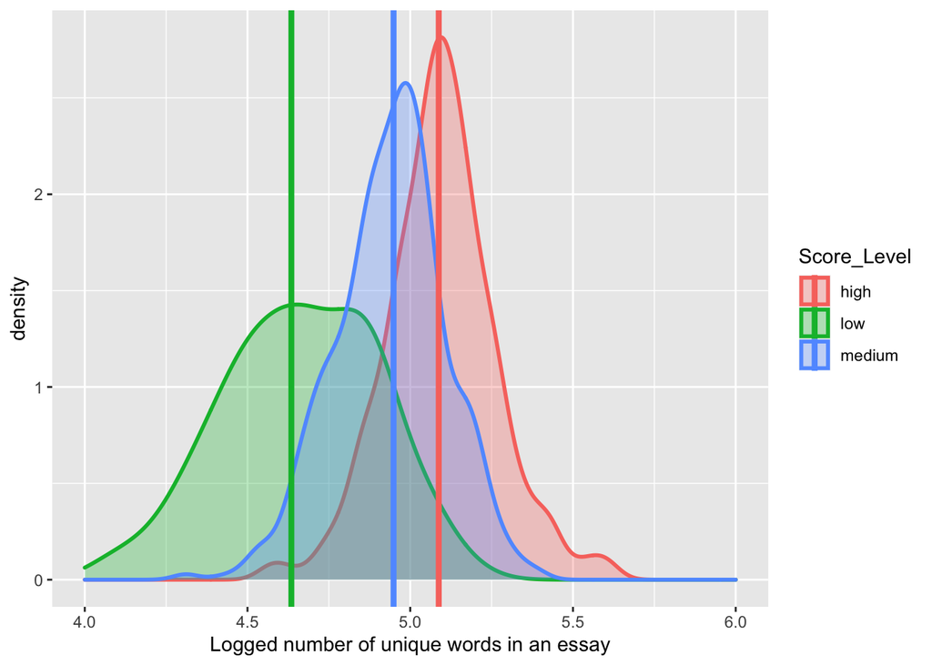

```r
num_uniq_word_by_score_mandarin <- combined_mandarin %>%
  group_by(Score_Level) %>%
  summarize(median=median(log(num_uniq_word)))

combined_mandarin %>%
  ggplot(aes(x=log(num_uniq_word), color=Score_Level, fill=Score_Level)) +
  geom_density(alpha=0.3,size=1)+
  xlim(4,6)+
  geom_vline(data=num_uniq_word_by_score_mandarin, aes(xintercept = median, color = Score_Level), size=1.5)+
  labs(x= "Logged number of unique words in an essay")
```

```r
  theme(legend.position="bottom")
```

```
## List of 1
##  $ legend.position: chr "bottom"
##  - attr(*, "class")= chr [1:2] "theme" "gg"
##  - attr(*, "complete")= logi FALSE
##  - attr(*, "validate")= logi TRUE
```

Spanish L1 corpus

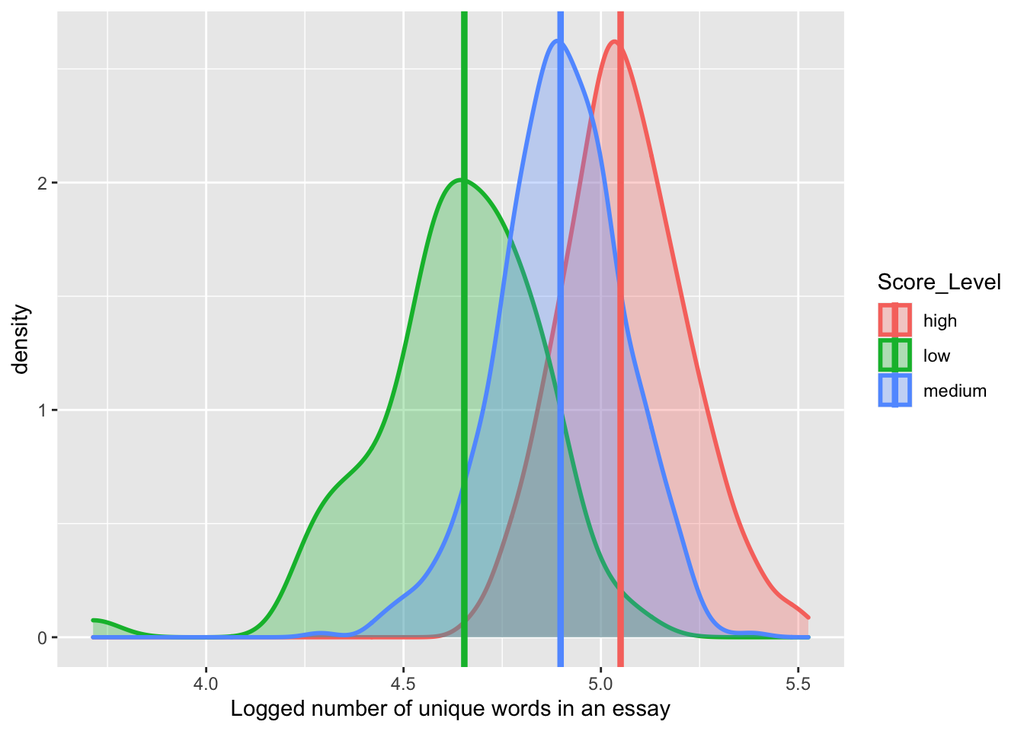

```r
num_uniq_word_by_score_spanish <- combined_spanish %>%
  group_by(Score_Level) %>%
  summarize(median=median(log(num_uniq_word)))

combined_spanish %>%
  ggplot(aes(x=log(num_uniq_word), color=Score_Level, fill=Score_Level)) +
  geom_density(alpha=0.3,size=1)+
  geom_vline(data=num_uniq_word_by_score_spanish, aes(xintercept = median, color = Score_Level), size=1.5)+
  labs(x= "Logged number of unique words in an essay")
```

PCA based on sentence complexity metrics, Mandarin L1 corpus Out of the two significant principle values, PC2 seems to have the more positive effect. Number of unique words is the most important factor in PC2. This shows that number of unique words is the best predictor for essay’s score levels

```r
sent_complex_mandarin <-
  combined_mandarin %>%
  mutate(avg_sent_len=essay_len/num_sentence) %>%
  mutate(the_aan_ratio=the_count/(aan_count + 1)) %>%
  mutate(score_level_num=ifelse(Score_Level=="low", 1, ifelse(Score_Level=="medium", 2, 3))) %>%
  select(noun_per_sentence, num_uniq_word, avg_sent_len, Score_Level, score_level_num)

(sent_complex_pca_mandarin <-
  prcomp(sent_complex_mandarin[c('noun_per_sentence', 'num_uniq_word', 'avg_sent_len')],center=T, scale=T))
```

```
## Standard deviations (1, .., p=3):
## [1] 1.4017917 0.9727581 0.2978616
##
## Rotation (n x k) = (3 x 3):
##                         PC1        PC2         PC3
## noun_per_sentence 0.6914762 -0.1284386 -0.71088972
## num_uniq_word     0.2347676  0.9706059  0.05299403
## avg_sent_len      0.6831873 -0.2035380  0.70130410
```

```r
sent_complex_pca_mandarin$rotation
```

```
##                         PC1        PC2         PC3
## noun_per_sentence 0.6914762 -0.1284386 -0.71088972
## num_uniq_word     0.2347676  0.9706059  0.05299403
## avg_sent_len      0.6831873 -0.2035380  0.70130410
```

```r
summary(lm(sent_complex_mandarin$score_level_num
           ~ sent_complex_pca_mandarin$x[,"PC1"] +
               sent_complex_pca_mandarin$x[,"PC2"] +
               sent_complex_pca_mandarin$x[,"PC3"]))
```

```
##
## Call:
## lm(formula = sent_complex_mandarin$score_level_num ~ sent_complex_pca_mandarin$x[,
##     "PC1"] + sent_complex_pca_mandarin$x[, "PC2"] + sent_complex_pca_mandarin$x[,
##     "PC3"])
##
## Residuals:
##      Min       1Q   Median       3Q      Max
## -1.47983 -0.27429 -0.06438  0.26202  1.30575
##
## Coefficients:
##                                      Estimate Std. Error t value Pr(>|t|)
## (Intercept)                           2.16091    0.01433 150.759  < 2e-16 ***
## sent_complex_pca_mandarin$x[, "PC1"]  0.06361    0.01023   6.218 7.16e-10 ***
## sent_complex_pca_mandarin$x[, "PC2"]  0.29087    0.01474  19.731  < 2e-16 ***
## sent_complex_pca_mandarin$x[, "PC3"] -0.03271    0.04814  -0.680    0.497
## ---
## Signif. codes:  0 '***' 0.001 '**' 0.01 '*' 0.05 '.' 0.1 ' ' 1
##
## Residual standard error: 0.4754 on 1096 degrees of freedom
## Multiple R-squared:  0.2811, Adjusted R-squared:  0.2791
## F-statistic: 142.8 on 3 and 1096 DF,  p-value: < 2.2e-16
```

```r
sent_complex_spanish <-
  combined_spanish %>%
  mutate(avg_sent_len=essay_len/num_sentence) %>%
  mutate(the_aan_ratio=the_count/(aan_count + 1)) %>%
  mutate(score_level_num=ifelse(Score_Level=="low", 1, ifelse(Score_Level=="medium", 2, 3))) %>%
  select(noun_per_sentence, num_uniq_word, avg_sent_len, Score_Level, score_level_num)

(sent_complex_pca_spanish <-
  prcomp(sent_complex_spanish[c('noun_per_sentence', 'num_uniq_word', 'avg_sent_len')],center=T, scale=T))
```

```
## Standard deviations (1, .., p=3):
## [1] 1.3990376 0.9995895 0.2086015
##
## Rotation (n x k) = (3 x 3):
##                           PC1         PC2          PC3
## noun_per_sentence -0.70667135 -0.02834323 -0.706974024
## num_uniq_word      0.03072567 -0.99948405  0.009357715
## avg_sent_len      -0.70687449 -0.01510942  0.707177603
```

```r
sent_complex_pca_spanish$rotation
```

```
##                           PC1         PC2          PC3
## noun_per_sentence -0.70667135 -0.02834323 -0.706974024
## num_uniq_word      0.03072567 -0.99948405  0.009357715
## avg_sent_len      -0.70687449 -0.01510942  0.707177603
```

```r
summary(lm(sent_complex_spanish$score_level_num
           ~ sent_complex_pca_spanish$x[,"PC1"] +
               sent_complex_pca_spanish$x[,"PC2"] +
               sent_complex_pca_spanish$x[,"PC3"]))
```

```
##
## Call:
## lm(formula = sent_complex_spanish$score_level_num ~ sent_complex_pca_spanish$x[,
##     "PC1"] + sent_complex_pca_spanish$x[, "PC2"] + sent_complex_pca_spanish$x[,
##     "PC3"])
##
## Residuals:
##      Min       1Q   Median       3Q      Max
## -1.58068 -0.34040 -0.04959  0.41311  1.37835
##
## Coefficients:
##                                     Estimate Std. Error t value Pr(>|t|)
## (Intercept)                          2.34455    0.01512 155.112  < 2e-16 ***
## sent_complex_pca_spanish$x[, "PC1"]  0.03642    0.01081   3.369  0.00078 ***
## sent_complex_pca_spanish$x[, "PC2"] -0.34147    0.01513 -22.572  < 2e-16 ***
## sent_complex_pca_spanish$x[, "PC3"]  0.04246    0.07249   0.586  0.55820
## ---
## Signif. codes:  0 '***' 0.001 '**' 0.01 '*' 0.05 '.' 0.1 ' ' 1
##
## Residual standard error: 0.5013 on 1096 degrees of freedom
## Multiple R-squared:  0.3223, Adjusted R-squared:  0.3204
## F-statistic: 173.7 on 3 and 1096 DF,  p-value: < 2.2e-16
```

### “The” vs. demonstratives

Regression plots for the logged frequency of “the” and demonstratives against number of unique words

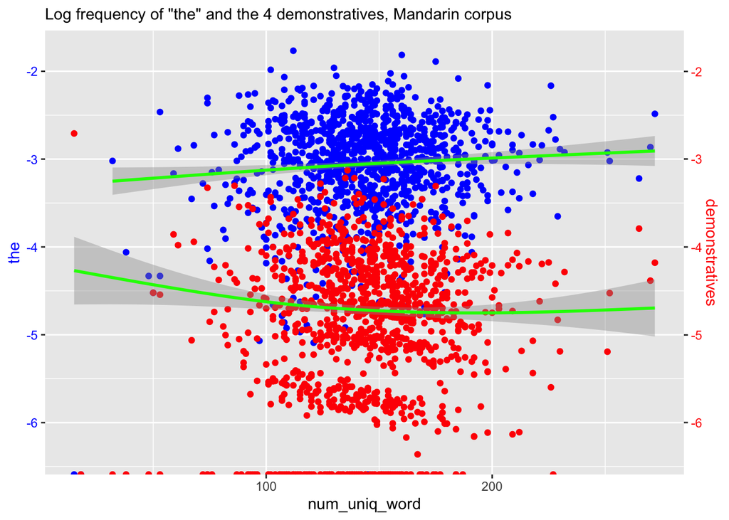

```r
ggplot(combined_mandarin, aes(x=num_uniq_word)) +
  geom_point(aes(y=log(the_freq)), col="blue") +
  geom_point(aes(y=log(this_freq+that_freq+these_freq+those_freq)), col="red") +
  geom_smooth(aes(y=log(the_freq)), col="green") +
  geom_smooth(aes(y=log(this_freq+that_freq+these_freq+those_freq)), col="green") +
  scale_y_continuous(name="the", sec.axis=sec_axis(~ ., name="demonstratives")) +
  theme(
    axis.title.y.left=element_text(color="blue"),
    axis.text.y.left=element_text(color="blue"),
    axis.title.y.right=element_text(color="red"),
    axis.text.y.right=element_text(color="red")
  ) +
  labs(subtitle="Log frequency of \"the\" and the 4 demonstratives, Mandarin corpus")
```

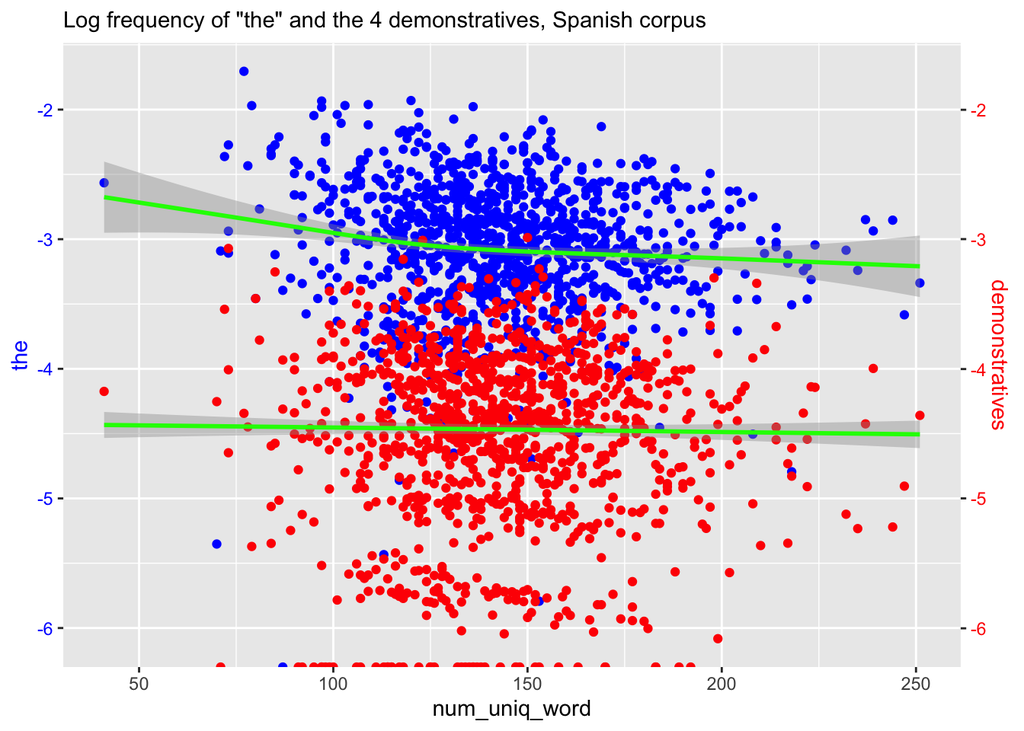

```r
ggplot(combined_spanish, aes(x=num_uniq_word)) +
  geom_point(aes(y=log(the_freq)), col="blue") +
  geom_point(aes(y=log(this_freq+that_freq+these_freq+those_freq)), col="red") +
  geom_smooth(aes(y=log(the_freq)), col="green") +
  geom_smooth(aes(y=log(this_freq+that_freq+these_freq+those_freq)), col="green") +
  scale_y_continuous(name="the", sec.axis=sec_axis(~ ., name="demonstratives")) +
  theme(
    axis.title.y.left=element_text(color="blue"),
    axis.text.y.left=element_text(color="blue"),
    axis.title.y.right=element_text(color="red"),
    axis.text.y.right=element_text(color="red")
  ) +
  labs(subtitle="Log frequency of \"the\" and the 4 demonstratives, Spanish corpus")
```

Density plots for the ratio between “the” and demonstratives for both corpora.

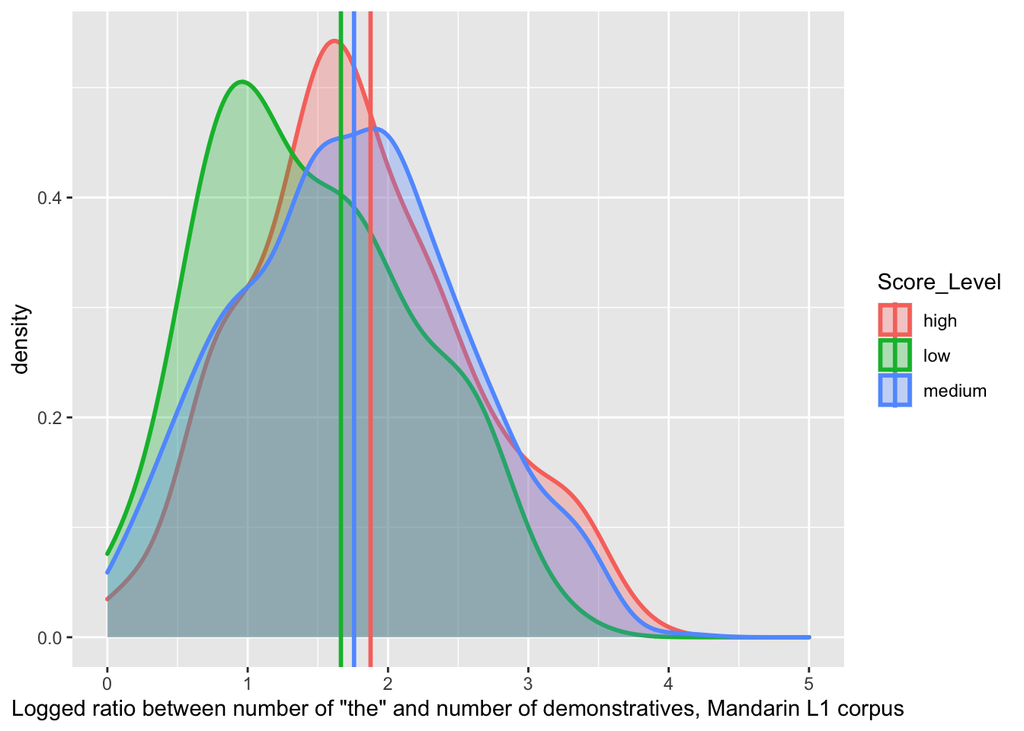

```r
the_demo_ratio_mandarin <- combined_mandarin %>%
  group_by(Score_Level) %>%
  summarize(average=mean(the_count/(this_count+these_count+that_count+those_count+1), na.rm=TRUE))%>%
  mutate(average=log(average))

combined_mandarin %>%
  ggplot(aes(x=log(the_count/(this_count+these_count+that_count+those_count)), color=Score_Level, fill=Score_Level)) +
  geom_density(alpha=0.3,size=1)+
  geom_vline(data=the_demo_ratio_mandarin, aes(xintercept = average, color = Score_Level), size=1)+
  xlim(0, 5) +
  labs(x= "Logged ratio between number of \"the\" and number of demonstratives, Mandarin L1 corpus")
```

Regression result between the ratio of demonstratives and “the” against number of unique words shows very low correlation.

```r
combined_mandarin_the_demo_ratio <- combined_mandarin %>%
  mutate(ratio=log(the_freq/(this_freq+that_freq+these_freq+those_freq))) %>%
  filter(ratio < 10000) %>%
  filter(ratio > -10000) %>%
  select(ratio, num_uniq_word)
summary(lm(combined_mandarin_the_demo_ratio$ratio ~ log(combined_mandarin_the_demo_ratio$num_uniq_word)))
```

```
##
## Call:
## lm(formula = combined_mandarin_the_demo_ratio$ratio ~ log(combined_mandarin_the_demo_ratio$num_uniq_word))
##
## Residuals:
##      Min       1Q   Median       3Q      Max
## -2.77171 -0.58686  0.00348  0.58321  2.38505
##
## Coefficients:
##                                                     Estimate Std. Error t value
## (Intercept)                                          -0.2254     0.6726  -0.335
## log(combined_mandarin_the_demo_ratio$num_uniq_word)   0.3779     0.1354   2.791
##                                                     Pr(>|t|)
## (Intercept)                                          0.73760
## log(combined_mandarin_the_demo_ratio$num_uniq_word)  0.00535 **
## ---
## Signif. codes:  0 '***' 0.001 '**' 0.01 '*' 0.05 '.' 0.1 ' ' 1
##
## Residual standard error: 0.8798 on 979 degrees of freedom
## Multiple R-squared:  0.007896,   Adjusted R-squared:  0.006883
## F-statistic: 7.792 on 1 and 979 DF,  p-value: 0.005351
```

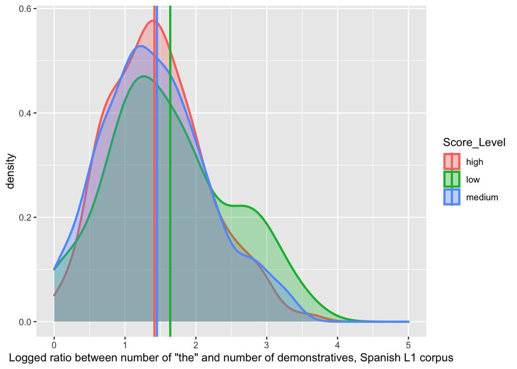

```r
the_demo_ratio_spanish <- combined_spanish %>%
  group_by(Score_Level) %>%
  summarize(average=mean(the_count/(this_count+these_count+that_count+those_count+1), na.rm=TRUE))%>%
  mutate(average=log(average))

combined_spanish %>%
  ggplot(aes(x=log(the_count/(this_count+these_count+that_count+those_count)), color=Score_Level, fill=Score_Level)) +
  geom_density(alpha=0.3,size=1)+
  geom_vline(data=the_demo_ratio_spanish, aes(xintercept = average, color = Score_Level), size=1)+
  xlim(0, 5) +
  labs(x= "Logged ratio between number of \"the\" and number of demonstratives, Spanish L1 corpus")
```

### “The” vs. “a”/“an”

In Mandarin L1 corpus, frequency of “a” and “an” increases slightly as number of unique words increases.

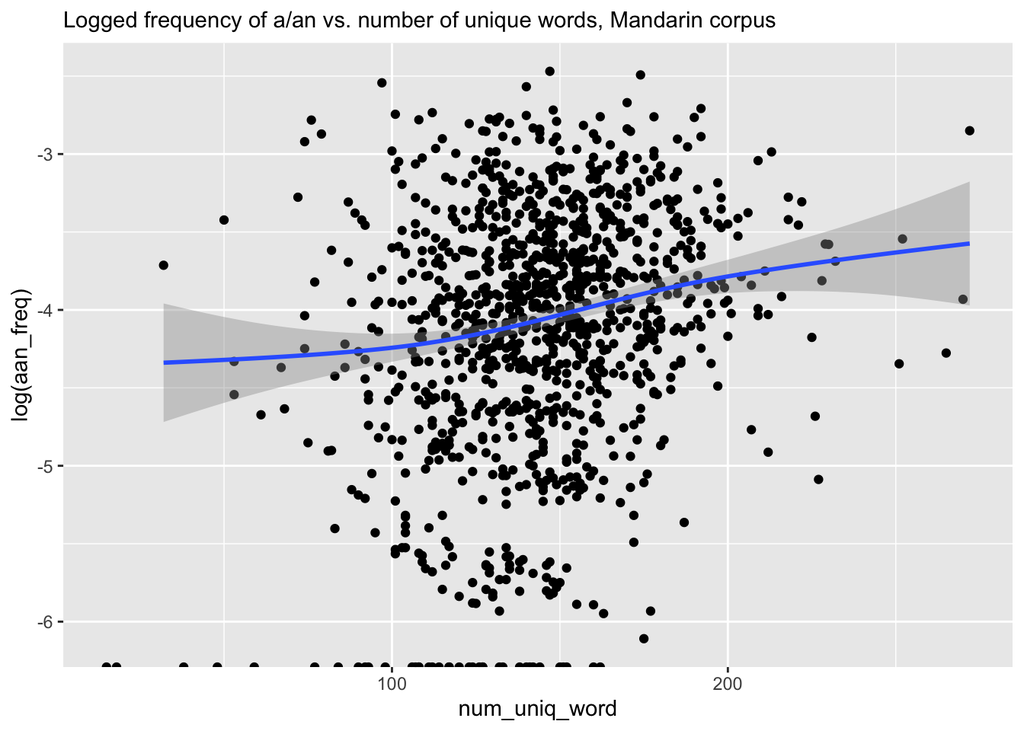

```r
combined_mandarin %>%
  ggplot(aes(x=num_uniq_word, y=log(aan_freq))) +
  geom_point() +
  stat_smooth() +
  labs(subtitle="Logged frequency of a/an vs. number of unique words, Mandarin corpus")
```

Density plot for ratio between “the” and “a/an”, Mandarin L1 corpus

```r
the_aan_ratio_mandarin <- combined_mandarin %>%
  group_by(Score_Level) %>%
  summarize(median=median(log(the_count/aan_count), na.rm=TRUE))
head(the_aan_ratio_mandarin)
```

```
## # A tibble: 3 x 2
##   Score_Level median
##   <chr>        <dbl>
## 1 high         0.847
## 2 low          1.12
## 3 medium       1.04
```

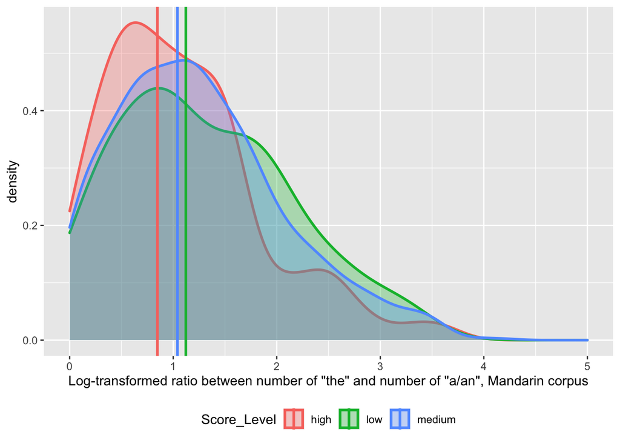

```r
combined_mandarin %>%
  ggplot(aes(x=log(the_count/aan_count), color=Score_Level, fill=Score_Level)) +
  geom_density(alpha=0.3,size=1)+
  geom_vline(data=the_aan_ratio_mandarin, aes(xintercept = median, color = Score_Level), size=1)+
  xlim(0, 5) +
  labs(x= "Log-transformed ratio between number of \"the\" and number of \"a/an\", Mandarin corpus")+
  theme(legend.position="bottom")
```

### “The” vs. Other Determiners

Density plots for the ratio between “the” and other determiners

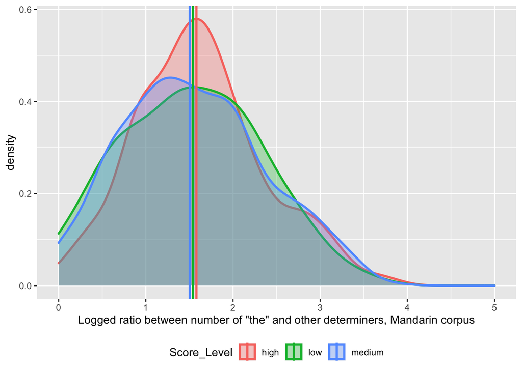

```r
the_other_ratio_mandarin <- combined_mandarin %>%
  group_by(Score_Level) %>%
  summarize(median=median(log(the_count/other_det_count), na.rm=TRUE))

combined_mandarin %>%
  ggplot(aes(x=log(the_count/other_det_count), color=Score_Level, fill=Score_Level)) +
  geom_density(alpha=0.3,size=1)+
  xlim(0, 5)+
  geom_vline(data=the_other_ratio_mandarin, aes(xintercept = median, color = Score_Level), size=1)+
  labs(x= "Logged ratio between number of \"the\" and other determiners, Mandarin corpus")+
  theme(legend.position="bottom")
```